# Data Challenge - Price Elasticity

Conversion Analysis Objective: Build quote-to-purchase conversion curve as a function of price

2018.10.21

```r
library(lubridate)
library(stringr)
library(ggplot2)
library(dplyr)
library(sqldf)
library(aod)
```

### Read in data

```r
#gsub('\\\\','/',readClipboard())
setwd(readClipboard())
df <-read.csv(gzfile('data_challenge_price.csv.gz','rt')
              , header=T
              , stringsAsFactors = F)
str(df)
```

```
'data.frame':   329097 obs. of  9 variables:
 $ business_id   : chr  "cdd69a9e27026cd2b0667d18b765c918" "cdd69a9e27026cd2b0667d18b765c918" "cdd69a9e27026cd2b0667d18b765c918" "cdd69a9e27026cd2b0667d18b765c918" ...
 $ cob_id        : int  5010 5010 5010 5010 5010 5010 5003 5003 5003 5003 ...
 $ state         : chr  "MO" "MO" "MO" "MO" ...
 $ bundle_name   : chr  "proPlus" "basicTria" "basic" "proPlusTria" ...
 $ status_name   : chr  "Quote" "Quote" "Quote" "Quote" ...
 $ yearly_premium: num  434 350 350 435 411 413 350 350 350 350 ...
 $ start_date    : chr  "2018-03-02" "2018-03-02" "2018-03-02" "2018-03-02" ...
 $ creation_time : chr  "2018-01-01 17:35:14.949" "2018-01-01 17:35:14.994" "2018-01-01 17:35:15.025" "2018-01-01 17:35:15.068" ...
 $ orig_premium  : chr  "" "" "" "" ...
```

### Quick glance

```r
sapply(df[c(2:5)], function(x) table(x))
```

```
$cob_id
x
  5003   5005   5006   5010 100001
 41652  44616 107088  32859 102882

$state
x
   AL    AR    AZ    CA    CO    CT    DC    DE    GA    IA    ID    IL    IN    KS    KY
 7710  2310  5698 23838 17580  4866   204  2166 16050  3450  3102 14652  9120  3516  6888
   LA    MA    MD    ME    MI    MN    MO    MS    MT    NC    ND    NE    NH    NJ    NM
 1823  4938  5004  2844 15462  5658  9498  3084  1968 12894   492  2076  2766 15834  1464
   NV    OH    OK    OR    PA    RI    SC    SD    TN    TX    UT    VA    VT    WI    WV
 1872 15210  2238  4200 21210  1716  8958   852  9282 34842  2730  7998  1062  7212  2406
   WY
  354

$bundle_name
x
      basic   basicTria         pro     proPlus proPlusTria     proTria
      55087       54802       54802       54802       54802       54802

$status_name
x
  Active Canceled    Quote Selected
    7281     1407   297252    23157
```

```r
nrow(unique(df[1]))
```

```
[1] 30650
```

```r
summary(df$yearly_premium)
```

```
    Min.  1st Qu.   Median     Mean  3rd Qu.     Max.
     350      396      750    25873      944 56822079
```

Buz ID: 30650 Cob_ID: 5 State: 46 Bundle: 6

### Not sure why orig_premium is double-quoted, change type

```r
df$orig_premium1 <- as.numeric(str_sub(df$orig_premium, 2, -2))
##Checking
y <- df[is.na(df$orig_premium1)==F, c("yearly_premium", "orig_premium", "orig_premium1")]
y <- unique(y[order(y$orig_premium1),])
head(y); tail(y)
```

|  | yearly_premium | orig_premium | orig_premium1 |
| --- | --- | --- | --- |
| 209986 | 750 | "0.00472318341957" | 0.004723183 |
| 277782 | 750 | "0.0053510281875" | 0.005351028 |
| 232574 | 750 | "0.0057448638621" | 0.005744864 |
| 209990 | 750 | "0.006751868903766316" | 0.006751869 |
| 209988 | 750 | "0.007231103844292263" | 0.007231104 |
| 277783 | 750 | "0.007630474671388881" | 0.007630475 |

|  | yearly_premium | orig_premium | orig_premium1 |
| --- | --- | --- | --- |
| 205424 | 22107385 | "2.2107385163794074E7" | 22107385 |
| 205423 | 22202471 | "2.2202470693794075E7" | 22202471 |
| 205426 | 30398338 | "3.039833773296213E7" | 30398338 |
| 205425 | 30523573 | "3.052357292296213E7" | 30523573 |
| 205427 | 32036154 | "3.2036153795762673E7" | 32036154 |
| 205422 | 32162923 | "3.2162923005762674E7" | 32162923 |

If orig_premium represents the premium before rounding up to the minimum, some prices seem to be ridiculously too low for a sound policy. We wouldn’t use it to construct price elasticity curves.

### Highly skewed yearly premium

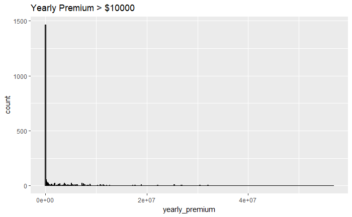

```r
ggplot(data = df[df$yearly_premium > 10000, ], aes(x = yearly_premium)) +
  geom_histogram(bins= 500, color = 'black') +
  ggtitle("Yearly Premium > $10000")
```

### Premium range by state, cob

```r
premium_range <-
  df %>% group_by(state, cob_id) %>%
         summarise(minPrem = min(yearly_premium)
                   ,maxPrem = max(yearly_premium))
##Fluctuation of state-cob specific premium range
premium_range %>% group_by(cob_id) %>%
                  summarise(min_minPrem = min(minPrem)
                            ,max_minPrem = max(minPrem)
                            ,min_maxPrem = min(maxPrem)
                            ,max_maxPrem = max(maxPrem))
```

| cob_id | min_minPrem | max_minPrem | min_maxPrem | max_maxPrem |
| --- | --- | --- | --- | --- |
| 5003 | 350 | 450 | 450 | 9796762 |
| 5005 | 350 | 562 | 2199 | 56822079 |
| 5006 | 350 | 572 | 755 | 33723884 |
| 5010 | 350 | 450 | 350 | 41298974 |
| 100001 | 750 | 764 | 1599 | 20788185 |

Minimum premium set to $350, fluctuates ~$100 - $200 across states, depending on cob.

### Select premium

```r
#g <- function(x) c(n = length(x), quantile(x, c(0, 0.25, 0.5, 0.75, 0.9, 0.99, 1)))
#tapply(df$yearly_premium, df$status_name, g)
df %>% group_by(status_name) %>%
       summarise(n = n()
                  ,min = min(yearly_premium)
                  ,q25 = quantile(yearly_premium, 0.25)
                 ,q50 = quantile(yearly_premium, 0.5)
                 ,q75 = quantile(yearly_premium, 0.75)
                 ,q90 = quantile(yearly_premium, 0.9)
                 ,q99 = quantile(yearly_premium, 0.99)
                 ,max = max(yearly_premium)
    )
```

| status_name | n | min | q25 | q50 | q75 | q90 | q99 | max |
| --- | --- | --- | --- | --- | --- | --- | --- | --- |
| Active | 7281 | 350 | 361 | 562 | 750 | 1126 | 3033.60 | 13145 |
| Canceled | 1407 | 350 | 358 | 581 | 754 | 1226 | 3357.96 | 11127 |
| Quote | 297252 | 350 | 398 | 750 | 955 | 1839 | 8068.45 | 56822079 |
| Selected | 23157 | 350 | 396 | 748 | 913 | 1597 | 6277.00 | 53632126 |

```r
### Pick latest quote per status
#   If any quote is purchased (status of Active or Canceled), use the associated premium
# Else, if any quote is selected (meaning the user has selected that package and clicked through to the payment screen), use the associated premium from the latest quote
# Else, use the associated premium from the latest quote for the Pro bundle
### Assume one staus per business id regardless of state
last_quote <- sqldf("select *, case when status_name in ('Active', 'Canceled') then 1
                                   when status_name = 'Selected' then 2
                                   when status_name = 'Quote' and bundle_name = 'pro' then 3
                                   else 4
                                   end as s
                         From df
                         group by business_id, s
                         having creation_time = max(creation_time)
                         order by business_id, s")
### Check if business with only Quote status always have pro bundle
Quote <- sqldf("select * From last_quote where business_id not in
                (select business_id from last_quote where s in (1,2))")
DFO <- sqldf("select business_id from Quote where status_name = 'Quote' and bundle_name != 'pro'
              except
              select business_id from Quote where status_name = 'Quote' and bundle_name = 'pro'")
### -> 0 count, Yes!
status <- sqldf("select *
                ,case when s =1 then 1 else 0 end as Converted
                From last_quote
                  group by business_id
                  having s = min(s)") # --> get back 30650 unique business id!
table(status[status$s==3, ]$bundle_name) #--> if status = Quote, bundle = pro!
```

```
 pro
9763
```

```r
table(status$status_name)
```

```
  Active Canceled    Quote Selected
    7280     1355     9763    12252
```

### Coversion rate

```r
### Overall
round(prop.table(table(status$Converted))*100, 2)
```

```
    0     1
71.83 28.17
```

```r
#tapply(status$Converted, status$cob_id, function(x) prop.table(table(x)))
```

28% converted overall

### By business class

```r
### Tabulate
status %>% group_by(cob_id) %>% summarise('Conversion%' = round(mean(Converted)*100, 2)) %>%
                                arrange(desc(.$'Conversion%'))
```

| cob_id | Conversion% |
| --- | --- |
| 5005 | 33.66 |
| 5010 | 31.07 |
| 5006 | 27.80 |
| 100001 | 26.36 |
| 5003 | 25.34 |

```r
### Statistical test
status$cob_id <- factor(status$cob_id)
logit_cob <- glm(Converted ~ cob_id, data = status, family = "binomial")
#summary(logit_cob)
wald.test(b = coef(logit_cob), Sigma = vcov(logit_cob), Terms = 2:5)
```

```
Wald test:
----------

Chi-squared test:
X2 = 107.7, df = 4, P(> X2) = 0.0
```

Conversion% significantly different between business classes

### By State

```r
### Tabulate
Conv_State <- status %>%
              group_by(state) %>%
              summarise(conversion_rate = round(mean(Converted)*100, 2)) %>%
              arrange(desc(.$conversion_rate))
Conv_State
```

| state | conversion_rate |
| --- | --- |
| RI | 48.24 |
| DC | 46.67 |
| NH | 40.23 |
| MA | 39.66 |
| CO | 36.45 |
| ME | 35.13 |
| MT | 34.86 |
| MN | 33.40 |
| CA | 32.32 |
| ID | 32.03 |

[output cut: 36 more lines]

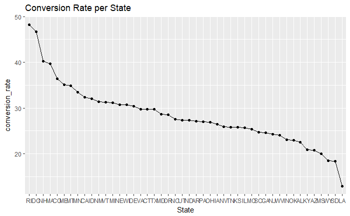

```r
### Visualize
ggplot(data = Conv_State, aes(x = reorder(state, -conversion_rate), y = conversion_rate))+
  geom_point() +
  geom_line(group=1) +
  labs(x = 'State') +
  ggtitle("Conversion Rate per State")
```

```r
### Statistical test
logit_state <- glm(Converted ~ state, data = status, family = "binomial")
#summary(logit_state)
wald.test(b = coef(logit_state), Sigma = vcov(logit_state), Terms = 2:46)
```

```
Wald test:
----------

Chi-squared test:
X2 = 325.4, df = 45, P(> X2) = 0.0
```

Conversion% significantly different between states, ranging from 13% to 48%

### By pricing bin

```r
### Distribution of premium per converted status
g <- function(x) c(n = length(x), quantile(x, c(0, 0.25, 0.5, 0.75, 0.9, 0.99, 1)))
tapply(status$yearly_premium, status$Converted, g)
```

```
$`0`
         n         0%        25%        50%        75%        90%        99%       100%
   22015.0      350.0      447.0      750.0     1166.0     2238.2    10048.2 53632126.0

$`1`
       n       0%      25%      50%      75%      90%      99%     100%
 8635.00   350.00   361.00   566.00   750.00  1143.00  3174.98 13145.00
```

```r
### Highly skewed distribution, zoom in to just premium < $1500 and see how conversion varies
# ggplot(status[status$yearly_premium <=1500, ],
#        aes(x=bin10, color =as.factor(Converted))) +
#   geom_histogram(fill="white", binwidth = 10, stat = 'count') +
#   ggtitle('Conversion vs Premium')
### Cut into $10 increments, 116 buckets
cutoff <- seq(350, 1500, 10)
status$bin10 <- cut(status$yearly_premium, breaks = cutoff, right = F, labels = F)
status[is.na(status$bin10), ]$bin10 <- 116
x <- status %>% group_by(bin10) %>%
                summarise(min = min(yearly_premium)
                          ,max = max(yearly_premium))
#tail(x)
Conv_bin10 <- status %>%
              group_by(bin10) %>%
              summarise(conversion_rate = round(mean(Converted)*100, 2))
Conv_bin10 <- sqldf("select x.*, b.conversion_rate
                    from x left join Conv_bin10 b
                    on x.bin10 = b.bin10")
Conv_bin10
```

| bin10 | min | max | conversion_rate |
| --- | --- | --- | --- |
| 1 | 350 | 359 | 34.01 |
| 2 | 360 | 369 | 43.60 |
| 3 | 370 | 379 | 42.07 |
| 4 | 380 | 389 | 42.59 |
| 5 | 390 | 399 | 38.49 |
| 6 | 400 | 409 | 39.87 |
| 7 | 410 | 419 | 40.67 |
| 8 | 420 | 429 | 37.92 |
| 9 | 430 | 439 | 38.69 |
| 10 | 440 | 449 | 33.70 |

[output cut: 106 more lines]

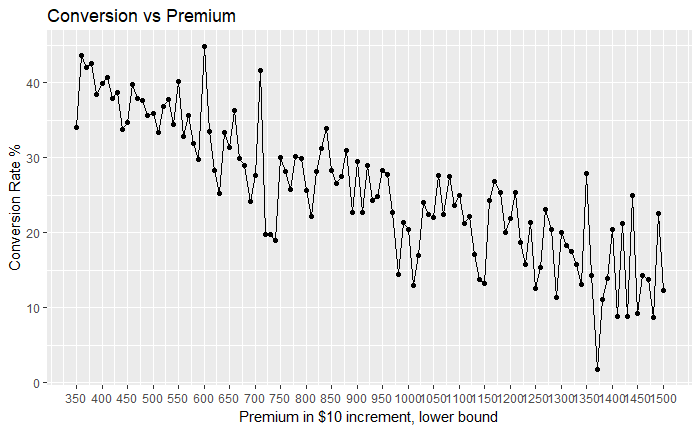

```r
ggplot(data=Conv_bin10,aes(x=min, y=conversion_rate)) +
  geom_point() +
  geom_line(group=1) +
  scale_x_continuous(breaks=seq(350,1500,50)) +
  labs(x = 'Premium in $10 increment, lower bound'
       ,y = 'Conversion Rate %') +
  ggtitle('Conversion vs Premium')
```

This price elasticity curve makes sense as we would expect more people to buy an insurance policy at a lower price.

### Based on the line graph, re-bin premium into smaller number of buckets

```r
mean(status[status$yearly_premium >=350 & status$yearly_premium <360, ]$Converted) #34.0%
```

```
[1] 0.3401469
```

```r
mean(status[status$yearly_premium >=360 & status$yearly_premium <440, ]$Converted) #40.7%
```

```
[1] 0.4070143
```

```r
mean(status[status$yearly_premium >=440 & status$yearly_premium <600, ]$Converted) #35.4%
```

```
[1] 0.3538642
```

```r
mean(status[status$yearly_premium >=600 & status$yearly_premium <720, ]$Converted) #32.7%
```

```
[1] 0.3265661
```

```r
mean(status[status$yearly_premium >=720 & status$yearly_premium <1000, ]$Converted) #28.4
```

```
[1] 0.2839477
```

```r
mean(status[status$yearly_premium >=1000 & status$yearly_premium <1360, ]$Converted) #20.4%
```

```
[1] 0.2041667
```

```r
mean(status[status$yearly_premium >=1360, ]$Converted) #11.9%
```

```
[1] 0.1189343
```

```r
# ggplot(status[status$yearly_premium <=1500, ],
#        aes(x=yearly_premium, color =as.factor(Converted))) +
#   geom_histogram(fill="white", binwidth = 10) +
#   ggtitle('Conversion vs Premium')

status$bin <- ifelse(status$yearly_premium >=350 & status$yearly_premium <360, '1-350-359',
                     ifelse(status$yearly_premium >=360 & status$yearly_premium <440, '2-360-439',
                      ifelse(status$yearly_premium >=440 & status$yearly_premium <600, '3-440-599',
                        ifelse(status$yearly_premium >=600 & status$yearly_premium <720, '4-600-719',
                          ifelse(status$yearly_premium >=720 & status$yearly_premium <1000, '5-720-999',
                          ifelse(status$yearly_premium >=1000 & status$yearly_premium <1360, '6-1000-1359',
                            ifelse(status$yearly_premium >=1360, '7-1360+', 'NA')))))))
status$bin <-factor(status$bin)
###Check binning
tapply(status$yearly_premium, status$bin, range)
```

```
$`1-350-359`
[1] 350 359

$`2-360-439`
[1] 360 439

$`3-440-599`
[1] 440 599

$`4-600-719`
[1] 600 719

$`5-720-999`
[1] 720 999

$`6-1000-1359`
[1] 1000 1359

$`7-1360+`
[1]     1360 53632126
```

```r
### Tabulate
Conv_bin <- status %>%
              group_by(bin) %>%
              summarise(conversion_rate= round(mean(Converted)*100, 2)
                        ,n = n()) %>%
              arrange(desc(.$conversion_rate))
Conv_bin
```

| bin | conversion_rate | n |
| --- | --- | --- |
| 2-360-439 | 40.70 | 2167 |
| 3-440-599 | 35.39 | 4270 |
| 1-350-359 | 34.01 | 6262 |
| 4-600-719 | 32.66 | 1724 |
| 5-720-999 | 28.39 | 8572 |
| 6-1000-1359 | 20.42 | 2400 |
| 7-1360+ | 11.89 | 5255 |

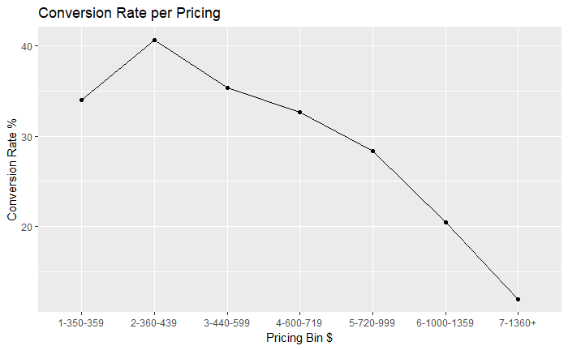

```r
### Visualize
ggplot(data = Conv_bin, aes(x = bin,
            #x = reorder(bin2, conversion_rate),
           y = conversion_rate))+
  geom_point() +
  geom_line(group=1) +
  labs(x = 'Pricing Bin $'
       ,y = 'Conversion Rate %') +
  ggtitle("Conversion Rate per Pricing")
```

```r
### Statistical test
logit_bin <- glm(Converted ~ bin, data = status, family = "binomial")
#summary(logit_bin)
wald.test(b = coef(logit_bin), Sigma = vcov(logit_bin), Terms = 2:7)
```

```
Wald test:
----------

Chi-squared test:
X2 = 1071.2, df = 6, P(> X2) = 0.0
```

Conversion% generally drops with increasing premium, and is significantly different between price buckets.

Also, highest conversion rate happens at $360-439. Does it suggset raising the minimum premium from $350 or is it just a minimum price per state requirement for certain business classes?

### Does binning effect change with business class?

```r
Conv_bin_cob <- status %>%
              group_by(cob_id, bin) %>%
              summarise(conversion_rate= round(mean(Converted)*100, 2)
                        ,n = n()) #%>%
              #arrange(desc(.$conversion_rate))
Conv_bin_cob
```

| cob_id | bin | conversion_rate | n |
| --- | --- | --- | --- |
| 5003 | 1-350-359 | 26.30 | 2836 |
| 5003 | 2-360-439 | 25.91 | 220 |
| 5003 | 3-440-599 | 25.20 | 615 |
| 5003 | 4-600-719 | 24.74 | 97 |
| 5003 | 5-720-999 | 17.32 | 127 |
| 5003 | 6-1000-1359 | 26.03 | 73 |
| 5003 | 7-1360+ | 8.57 | 105 |
| 5005 | 1-350-359 | 41.35 | 624 |
| 5005 | 2-360-439 | 44.82 | 618 |
| 5005 | 3-440-599 | 40.15 | 1041 |

[output cut: 21 more lines]

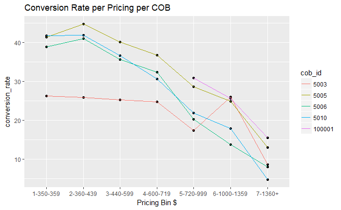

```r
### Visualize
ggplot(data = Conv_bin_cob, aes(x = bin,
                                #x = reorder(bin2, conversion_rate),
                                y = conversion_rate)) +
  geom_point() +
  geom_line(aes(group=cob_id, color=cob_id)) +
  labs(x = 'Pricing Bin $') +
  ggtitle("Conversion Rate per Pricing per COB")
```

Conversion trending generally looks similar across all business classes except for 5003 that shows the highest conversion rate of 26.3% at $350-$359 range. For class 100001, premium starts at $720-$999 range. It’s also the same range where the highest conversion hits.

### Does binning effect change with state?

```r
Conv_bin_state <- status %>%
              group_by(state, bin) %>%
              summarise(conversion_rate= round(mean(Converted)*100, 2)
                        ,n = n()) #%>%
              #arrange(desc(.$conversion_rate))
Conv_bin_state
```

| state | bin | conversion_rate | n |
| --- | --- | --- | --- |
| AL | 1-350-359 | 23.03 | 152 |
| AL | 2-360-439 | 28.33 | 60 |
| AL | 3-440-599 | 18.75 | 80 |
| AL | 4-600-719 | 35.56 | 45 |
| AL | 5-720-999 | 27.08 | 144 |
| AL | 6-1000-1359 | 18.31 | 71 |
| AL | 7-1360+ | 13.71 | 124 |
| AR | 1-350-359 | 35.80 | 81 |
| AR | 2-360-439 | 35.29 | 17 |
| AR | 3-440-599 | 33.33 | 12 |

[output cut: 294 more lines]

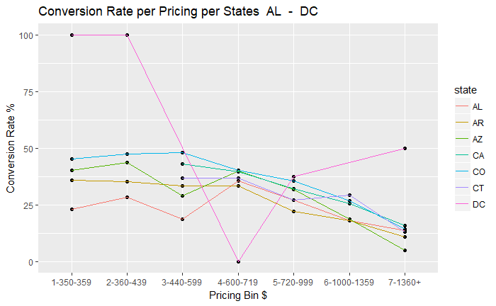

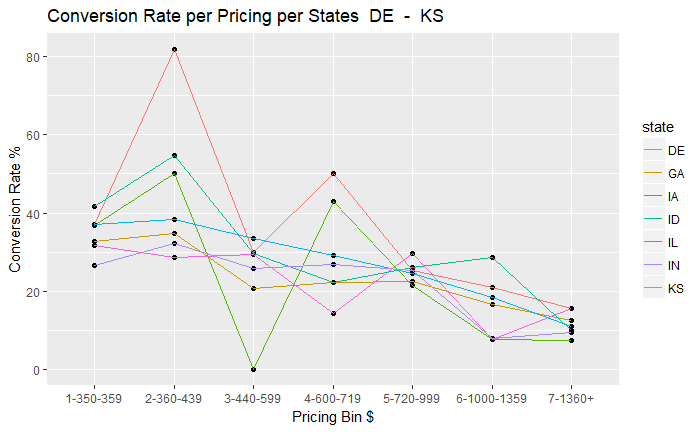

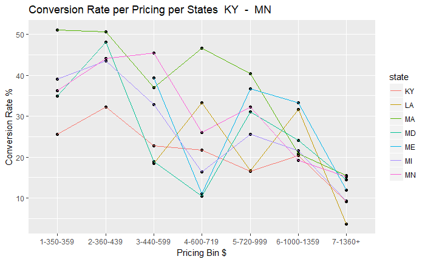

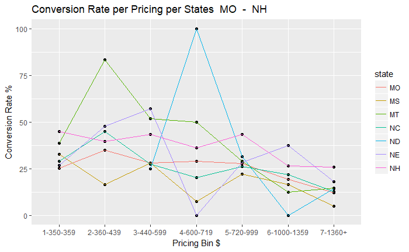

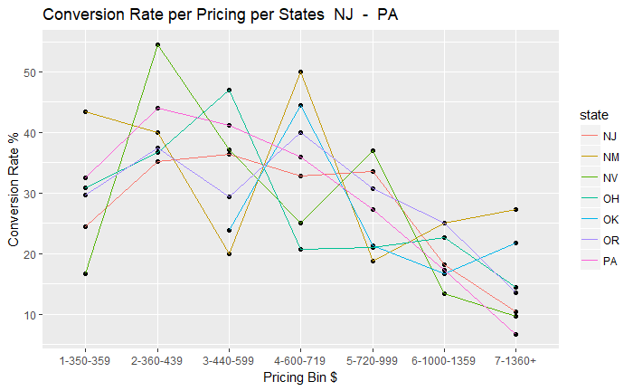

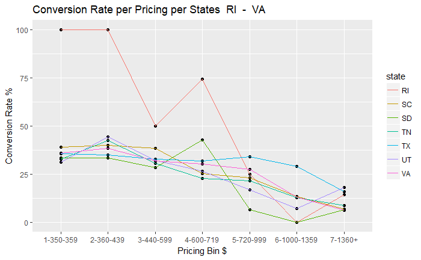

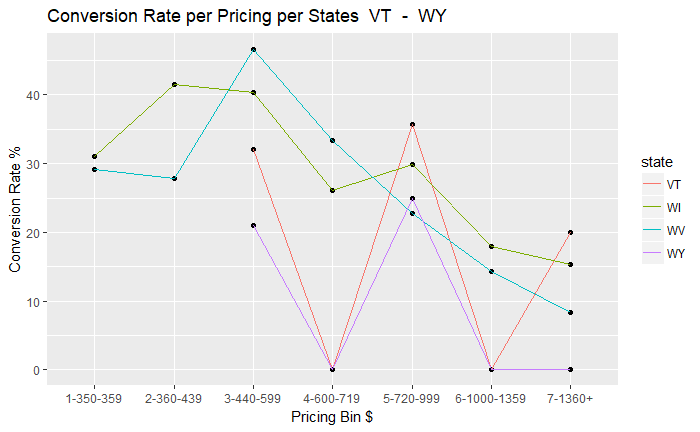

```r
### Visualize
### 7 states at a time
st <- sort(unique(Conv_bin_state$state))
for (k in 0:6){
  i=1+k*7
  if (k==6){
    j=46
  }
  else{
      j=7+k*7
  }
p <- ggplot(data = Conv_bin_state[Conv_bin_state$state %in% st[i:j], ]
            , aes(x = bin,
                  #x = reorder(bin, conversion_rate),
                  y = conversion_rate)) +
    geom_point() +
    geom_line(aes(group=state, color=state)) +
    labs(x = 'Pricing Bin $'
         ,y = 'Conversion Rate %') +
    ggtitle(paste("Conversion Rate per Pricing per States ", st[i], " - ", st[j]))
print(p)
}
```

Setting minimum premium should take factors like business class and state into consideration, because different business classes may have different risk levels to protect and different states may have different concentrations of business and regulations. Also, when looking at favorable pricing in terms of conversion, one needs to also look at the size of converted pool – are we talking about 9 cases out of 10 or 900 cases out of 1000 being converted? Basing minimum premium on sparse data can lead to unreliable results.